# Developing your personal workflow for transparent & reproducible research

Handout

Frederik Aust & Johannes Breuer

June 9th, 2019

Please link to [workshop GitHub repository](https://github.com/crsh/psych-transparency-guide_workshop/) and cite [Klein et al. (2018)](https://doi.org/10.1525/collabra.158).

# 1 General considerations

> Open Science is just science done right  
> —Jon Tennant, Imperial College London

> … until recently I was an open-data hypocrite. Although I was committed to open data, I was not implementing it in practice. … Some of it was a lack of effort. It was a pain to document the data; it was a pain to format the data; it was a pain to contact the library personnel; it was a pain to figure out which data were indeed published as part of which experiments. Some of it was forgetfulness. I had neither a routine nor any daily incentive to archive data (p. 1063, [Rouder, 2016](https://doi.org/10.3758/s13428-015-0630-z))

## 1.1 General recommendations

- Make transparency your default
  - Share all research products (as early as possible)
  - Declare and justify constraints on transparency
- Make transparency a by-product of your workflow
  - Create and use templates
  - Automate what can be automated
- Iteratively improve your workflow

> do not let the perfect be the enemy of the good. Share and document what you can, as it will provide a benefit compared with not sharing (p. 4, [Klein et al., 2018](https://doi.org/10.1525/collabra.158)).

# 2 What can you share?

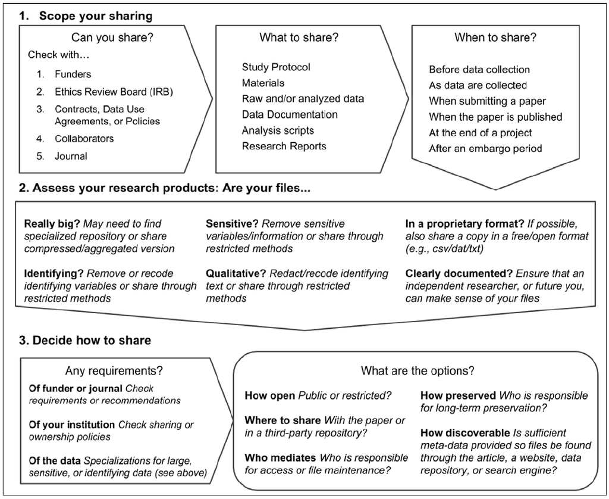

Figure 2.1: Decision flowchart outlining important considerations when sharing research products (reprinted from [Klein et al., 2018](https://doi.org/10.1525/collabra.158), [CC-BY Attribution 4.0](https://creativecommons.org/licenses/by/4.0/)).

## 2.1 Study protocol

- “Recipe for replication”
- Collates, describes, and organizes more specific research products
  - Hypotheses
  - Study materials
  - Detailed description of procedure
    - Instructive video documentation (e.g., [OBS](https://obsproject.com/) for computer-based studies)

## 2.2 Study materials

- Anything necessary to conduct the study, e.g.,
  - Questionnaires
  - Stimulus material
  - Computer code to present stimuli and collect responses
  - Instructions for interaction with participants
  - Scripts and instructions for confederates
- Mind intellectual property rights!

## 2.3 Data

- Include information about data sharing in informed consent (see [informed consent templates](http://psych-transparency-guide.uni-koeln.de//informed-consent.html) by Klein et al., 2018)
- Use open and interoperable file formats (e.g., CSV, TSV, JSON, ODS)
  - Use UTF-8 character encoding
- Raw data
  - As originally recorded (e.g., paper-pencil-questionnaires, CSV files, video recordings)
- Processed data
  - As used for analyses (e.g., coded, digitized, merged)
  - Ideally “Tidy Data” ([Wickham, 2014](https://www.jstatsoft.org/index.php/jss/article/view/v059i10/v59i10.pdf))
    1. Each measured variable in one column
    2. Different observation of the variables in different rows
    3. Multiple tables should include a column that allows them to be linked
- Participant privacy
  - [EU GDPR](http://www.eugdpr.org/): Data are personal if attributable to a specific person (using additional datasets if necessary)
    - [IAPP: How GDPR changes the rules for research](https://iapp.org/news/a/how-gdpr-changes-the-rules-for-research/)
    - Australian National Data Service: [Decision tree for sharing sensitive data](https://www.ands.org.au/__data/assets/pdf_file/0010/385309/sensitive-decision-tree.pdf)
  - Only collect the data you really need
  - Delete identifying information used for logistics as soon as possible (e.g., e-mail addresses)
  - Assess risk of reidentification, e.g.,
    - Small population and rare traits
    - Dyadic data
    - Hierarchical data (e.g., small subsamples of students, co-workers)
    - *Motivated intruder test* (e.g., jealous partner, nosy neighbor, envious co-worker, insurers, criminals)
  - Only share anonymized data publicly, e.g.,
    - Delete directly identifying information (e.g., full name, address, face, handwriting, date of birth, genetic information)
      - Mind combinations of indirect identifiers (e.g., ZIP code, gender, and date of birth, [Sweeney, 2000](https://dataprivacylab.org/projects/identifiability/paper1.pdf))
    - Separate demographics used for sample description and study data
    - Remove free text entries and alter them when citing in publications
    - If necessary, transform data, e.g.,
      - Binning
      - Top and bottom coding
      - Add noise
      - Aggregation
    - Use anonymization tools (e.g., [ARX](http://arx.deidentifier.org/), [Amnesia](https://amnesia.openaire.eu/index.html))
  - Control access to pseudonymized data

> To determine whether a natural person is identifiable, account should be taken of all the means reasonably likely to be used, such as singling out, either by the controller or by another person to identify the natural person directly or indirectly.  
> To ascertain whether means are reasonably likely to be used to identify the natural person, account should be taken of all objective factors, such as the costs of and the amount of time required for identification, taking into consideration the available technology at the time of the processing and technological developments. (Recital 26 EU GDPR)

## 2.4 Metadata

- Sampling procedure (who collected the data how, when, and where)
- Dataset, e.g.,
  - Number of observations
  - Name and description of variables (incl. source of a measure, information about translation)
  - Units of measurement, coding of values (e.g., “1 = Female”,“2 = Male”), possible options or range in which the data points can fall (e.g., “1 = not at all to 7 = Very much”)
  - Value(s) used for missing data
  - If necessary, how a variable was derived from other variables (e.g., “`bmi` was derived from body weight `m` and height `l` as $\mathrm{BMI} = \frac{m}{l^2}$.”)
- Can almost always be shared, even if raw or processed data cannot
- Automate codebook generation
  - Analysis software (e.g., [R `codebook` package](https://cran.r-project.org/web/packages/codebook/index.html), [SPSS codebook function](https://libguides.library.kent.edu/SPSS/Codebooks), or [Stata codebook function](http://www.stata.com/manuals13/dcodebook.pdf))
  - Specialized software (e.g., [Nesstar](http://www.nesstar.com/software/publisher.html), [DataWiz](https://datawiz.leibniz-psychology.org/DataWiz/?datawiz_locale=en))
- For data with high reuse value, consider using a standardized and machine-readable metadata format (e.g., [DDI](https://www.ddialliance.org/))
  - Some repositories provide implementation as a service

## 2.5 Documentation of analyses

- Exact specification of how to move from raw data to reported results (incl. data cleaning and transformation; see [supplementary material](http://psych-transparency-guide.uni-koeln.de/analytic-reproducibility.html#set-and-record-seeds-for-pseudorandom-number-generators) of Klein et al., 2018)
  - Step-by-step documentation for non-scriptable software programs
  - Analysis syntax
    - Avoid “works on my machine” errors (WOMME)
      - Relative file paths or permanent online sources
      - Avoid spaces and special characters
      - Test on another computer
    - Write reports as dynamic documents (e.g., R package [`papaja`](https://github.com/crsh/papaja))
  - Set and record seeds for pseudo-random number generators
- Share intermediate results for complex analyses
- Documentation of computational environment
  - Hardware
  - Software version incl. extensions
  - Containers and virtual machines (e.g., [Docker](https://www.docker.com/), [Vagrant](https://www.vagrantup.com/), [Singularity](https://www.sylabs.io/singularity/))

## 2.6 Research reports

- Paywalled publications (green open access, see Figure 2.2)
  - Preprint (initially submitted manuscript)
  - Postprint (accepted manuscript)
  - Mind journal policy (e.g., [SHERPA/RoMEO](http://www.sherpa.ac.uk/romeo/search.php), [Wikipedia list of journals by preprint policy](https://en.wikipedia.org/wiki/List_of_academic_journals_by_preprint_policy))
- Gold open access
  - Published article

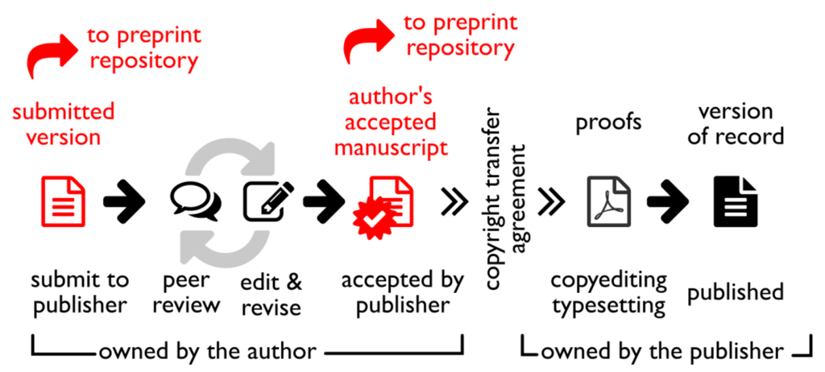

Figure 2.2: The typical editorial cycle of academic journals, preprints, and postprints (reprinted from [Marwick et al., 2017](http://www.saa.org/Portals/0/SAA_Record_Sept_2017_Final_LR.pdf#page=10), [CC-BY Attribution 4.0 International](https://creativecommons.org/licenses/by/4.0/)).

# 3 When can you share?

> any time is better than never (p. 4, [Klein et al., 2018](https://doi.org/10.1525/collabra.158)).

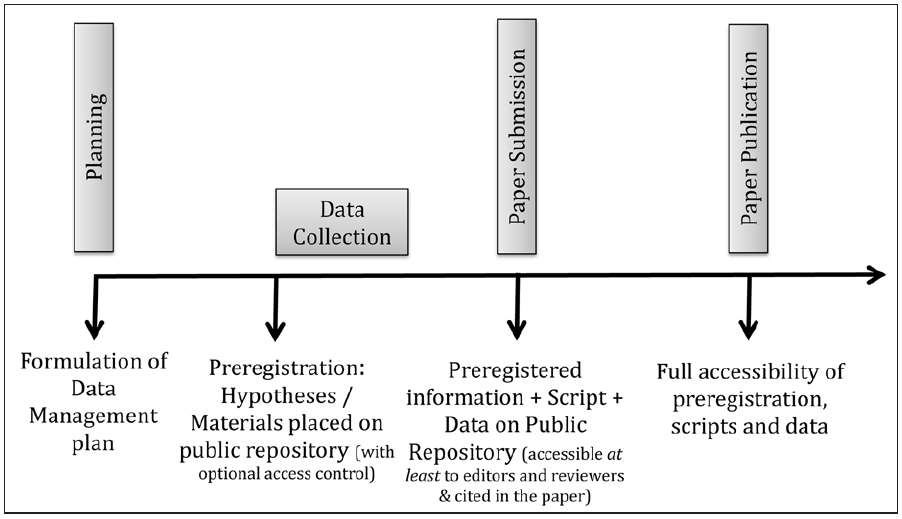

Figure 3.1: Typical workflow indicating when to share research products at different stages of the research process (reprinted from [Klein et al., 2018](https://doi.org/10.1525/collabra.158), [CC-BY Attribution 4.0](https://creativecommons.org/licenses/by/4.0/)).

## 3.1 Planning a study

- Have a *basic* data management plan (DMP), ideally before starting a project
  - Create basic reusable DMP templates
    - [ICPSR Framework for Creating a Data Management Plan](https://www.icpsr.umich.edu/icpsrweb/content/datamanagement/dmp/framework.html)
    - [DDC: How to Develop a Data Management and Sharing Plan](http://www.dcc.ac.uk/resources/how-guides/develop-data-plan)
  - Use online tools to get started (e.g., [ZPID DataWiz](https://datawiz.leibniz-psychology.org/DataWiz/?datawiz_locale=en), [DMPonline](https://dmponline.dcc.ac.uk/))
  - Simplifies addressing legal and ethical issues
  - Examples: [Public DMPs](https://dmponline.dcc.ac.uk/public_plans)

## 3.2 Before data collection

- Timely archiving
  - Study protocol and materials
  - Standard operating procedures
  - Analysis plan and scripts
- Preregistration

## 3.3 During data collection

- Born-open data ([Rouder, 2016](https://doi.org/10.3758/s13428-015-0630-z))
  - Automatically uploaded to a public repository
  - Offsite backup
  - But: Protect participants’ privacy!
  - Tutorial: [Born-open data with cloud storage providers](http://psych-transparency-guide.uni-koeln.de/born-open-data.html)

## 3.4 Upon submission

- Data, materials, and analysis scripts
  - Facilitates thorough peer-review
  - Errors can be spotted early on (no public correction)
  - Possibly limit access to reviewers prior to publications (e.g., [OSF view-only links](http://help.osf.io/m/links_forks/l/524049-create-a-view-only-link-for-a-project))
- Research report (see Figure 2.2)
  - Fast dissemination of results (citation advantage, e.g., [Piwowar & Vision, 2013](https://peerj.com/articles/175/))
  - Public peer review
  - Establishes precedents
  - Not typically considered a “prior publication” ([Bourne, Polka, Vale, & Kiley, 2017](https://doi.org/10.1371/journal.pcbi.1005473))
    - Exceptions: For example, *New England Journal of Medicine* and *Journal of Clinical Investigation*

## 3.5 After publication

- Archive continuously in online repository, publish later
- Automate by use of embargoes

# 4 How can you share?

## 4.1 Compilation of research products

- Develop a default project file structure
  - Klein et al. (2018) [example project](https://osf.io/rpydu/) and [ready-to-fork OSF template](https://osf.io/ep26s/)
    - Study protocol
    - Materials
    - Raw data
    - Processed data
    - Analyses
    - Research report
  - [TIER OSF template](https://osf.io/ybzxe/)
  - [BIDS example](https://github.com/INCF/BIDS-examples)
- If necessary, restrict repository access (e.g., [OSF components](http://help.osf.io/m/projects/l/481998-create-components))

## 4.2 Choose a repository

- Choose a suitable publicly accessible repository (Table 4.1)
  1. Stores data in accordance with local legislation (e.g., [EU GDPR](http://www.eugdpr.org/))
  2. Persistence guarantees for long-term access
  3. Persistent and unique identifiers (e.g., DOI)
  4. Features access controls (e.g., limit access to a select users; [GESIS secure data center](https://www.gesis.org/en/services/data-analysis/more-data-to-analyze/secure-data-center-sdc/))
  5. Supports systematic licensing (e.g., declare (no) legal restrictions on reuse)
  6. Supports structured metadata
  7. Tracks reuse of shared products (e.g., citations, downloads)
- [FAIR Data Principles](https://www.force11.org/group/fairgroup/fairprinciples) ([Wilkinson et al., 2016](https://doi.org/10.1038/sdata.2016.18))
  1. *Findable*: Persistent identifiers; metadata; indexed
  2. *Accessible*: Retrievable by identifier; controlled access where necessary
  3. *Interoperable*: Standardized metadata; open, lightweight, and interoperable file formats (e.g., CSV, TSV, JSON, ODS)
  4. *Reusable*: Documented; clear usage license
- Self-deposit (e.g., [OSF](https://osf.io/)) vs. curated repositories (e.g., [GESIS DBK](https://dbk.gesis.org/dbksearch/home.asp?db=e))
- Resources comparing repositories
  - Table 1 in [Klein et al. (2018)](https://doi.org/10.1525/collabra.158)
  - [Registry of Research Data Repositories](https://www.re3data.org/)
  - Dataverse blog: [Comparative review of various data repositories](https://dataverse.org/blog/comparative-review-various-data-repositories)
  - APS Observer: [Finding a Home for Your Science](https://www.psychologicalscience.org/observer/finding-a-home-for-your-science)
  - Table 1 in [Meyer (2018)](http://journals.sagepub.com/doi/abs/10.1177/2515245917747656)

Table 4.1: Heuristic ranking of sharing approaches

| Sharing option |  | Discoverability | Sustainability | Access control |
| --- | --- | --- | --- | --- |
| On request |  | – | – | ++ |
| Personal website |  | - | - | 0 |
| Journal website |  | + | 0 | 0 |
| Institutional repository |  | + | ++ | + |
| Public repository |  | ++ | ++ | + |

## 4.3 Licenses

- Licenses define conditions of use and redistribution
  - Specified by copyright holder
- Factual information are usually *not* protected by copyright
  - For example, response times, mortality rates, currency values, the number of Twitter followers someone has
  - Database structures and compilations of data may be copyrightable
- Copyright to long verbatim interview responses may belong to participants

> The selection, coordination, and arrangement of the database is subject to copyright if it is sufficiently original. […] The data or other contents contained in the database are subject to copyright if they are sufficiently creative. Original poems contained in a database would be protected by copyright, but purely factual data (such as gene names or city populations) would not. Facts are not subject to copyright, nor are the ideas underlying copyrighted content ([Creative Commons, 2018](https://wiki.creativecommons.org/wiki/Data)).
- Public availability does not authorize to reuse
  - Access categories vs. licenses
  - Always explicitly apply licenses
- Use easy-to-understand standard licenses
  - General purpose licenses (e.g., [Creative Commons](https://creativecommons.org/licenses/) , [Open data commons](https://opendatacommons.org/licenses/))
  - Specialized licenses
    - Data
      - [Open Data Commons](https://opendatacommons.org/licenses/index.html)
    - Software/code
      - [GNU General Public License](https://opensource.org/licenses/gpl-license)
      - [MIT License](https://opensource.org/licenses/MIT)
  - For example, include a license statement in a text file (“All files in this repository are licensed under a Creative Commons Zero License (CC0 1.0)”)
- Use most permissive license possible (e.g., CC0, CC-BY)

### 4.3.1 Creative Commons Licenses

- Modular license “building set” (see Table 4.2)
  - In practice, seven combinations are supported (see Figure 4.1)
- Mind version numbers (e.g., CC-BY 4.0)
- Copyright owner can always grant exceptions

Table 4.2: Overview of Create Commons (CC) modules

| License module |  | Abbreviation | Summary |
| --- | --- | --- | --- |
| [No rights reserved](https://creativecommons.org/publicdomain/zero/1.0/) |  | 0 | Waive all possible rights to work |
| [Attribution](https://creativecommons.org/licenses/by/4.0/) |  | BY | Prohibits reuse without citation |
| [Non-commercial](https://creativecommons.org/licenses/by-nc/4.0/) |  | NC | Prohibits commerical reuse |
| [Share-alike](https://creativecommons.org/licenses/by-sa/4.0/) |  | SA | Prohibits derived works under a different license |
| [No Derivatives](https://creativecommons.org/licenses/by-nd/4.0/) |  | ND | Prohibits any derived works |

[figure not shown]

Figure 4.1: Creative commons license spectrum between public domain (top) and all rights reserved (bottom; graphic by Shaddim, [CC-BY Attribution 4.0 International](https://creativecommons.org/licenses/by/4.0/), original CC license symbols by Creative Commons, [CC BY 4.0](https://creativecommons.org/licenses/by/4.0))

# 5 Learn more about transparent research practices

- [Open Science Knowledge Base](https://how-to-open.science/)
- [DataWiz Knowledge Base](https://datawizkb.leibniz-psychology.org/)
- [FOSTER Open Science Courses](https://www.fosteropenscience.eu/courses)
- [Center for Open Science Webinars](https://osf.io/qpxv2/)
- Data Sharing & FAIR Data Short Course at the [GESIS Summer School](https://training.gesis.org/?site=pDetails&child=full&pID=0xB455C10E4BA7451CBC729596CA4A2F4C&subID=0x46AC3A06211E4932A8FF77D60B2A6A30&lang=en_US)

# 6 Reading

Klein, O., Hardwicke, T. E., Aust, F., Breuer, J., Danielsson, H., Hofelich Mohr, A., … Frank, M. C. (2018). A Practical Guide for Transparency in Psychological Science. *Collabra: Psychology*, 4(1). doi: 10.1525/collabra.158 ([Supplementary material](http://psych-transparency-guide.uni-koeln.de/))

Handout for *Developing your personal workflow for transparent & reproducible research: Handout*, SIPS 2019, Rotterdam, Netherlands, June 9th, 2019.

Frederik Aust (frederik.aust@uni-koeln.de, [@frederikaust](http://twitter.com/frederikaust)); Johannes Breuer (johannes.breuer@gesis.org, [@MattEagle09](https://twitter.com/MattEagle09))

Please link to [workshop GitHub repository](https://github.com/crsh/psych-transparency-guide_workshop/) and cite [Klein et al. (2018)](https://doi.org/10.1525/collabra.158).

Icons by [Icons8](https://icons8.com), [CC-BY-ND 3.0](https://creativecommons.org/licenses/by-nd/3.0/).